# Make a world - Fishes

Daniel Ricard

Last modified timestap: 2021-02-03 10:24:04

Every year when I go to see during our annual southern Gulf of St. Lawrence survey, I keep thinking about how and why we collect fish otoliths.

In a given year, our technicians will spend months again otoliths. The process consists in preparing otoliths, reading them and noting the age of the individual that the animal came from.

What is this information used for?

How many otoliths do we need to age?

A more involved procedure consists in not only counting the rings on the otolith, but also measuring the growth increments visible on each otolith.

So let’s explore the trade-offs between ageing fish and obtaining age-length pairs versus ageing a fewer number of fish while measuring growth increments.

# Simulating fish growth

The commonly used von Bertalanffy model can be used to simulate age-length pairs, and also to simulate growth trajectories.

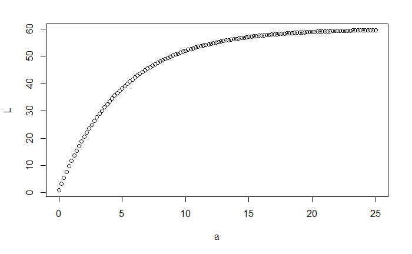

```r
ages <- seq(0,25,0.2)
vb.L0 <- 1
vb.Linf <- 60
vb.k <- -0.2

vb.f <- function(a){vb.Linf + (vb.L0 - vb.Linf) * exp(vb.k*a)}
lengths <- vb.f(ages)
vb.df <- data.frame(a=ages, L=lengths)
plot(L~a, data=vb.df)
```

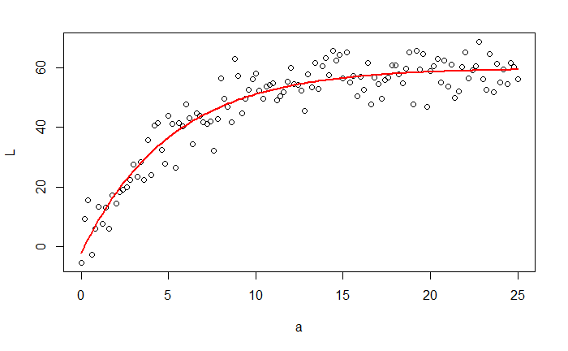

```r
## can we estimate this model?
# vb.fit <- nls(L ~ Linf + (L0-Linf) * exp(k * a), data=vb.df, start=list(Linf=60, k=-0.2, L0=1))

vb.df$L <-vb.df$L + rnorm(length(ages),0,5)
plot(L~a, data=vb.df)
vb.fit <- nls(L ~ Linf + (L0-Linf) * exp(k * a), data=vb.df, start=list(Linf=60, k=-0.2, L0=1))
lines(ages, predict(vb.fit), col="red", lwd=2)
```

```r
vb.fit
```

```
Nonlinear regression model
  model: L ~ Linf + (L0 - Linf) * exp(k * a)
   data: vb.df
   Linf       k      L0
59.7368 -0.1967 -2.1264
 residual sum-of-squares: 3644

Number of iterations to convergence: 4
Achieved convergence tolerance: 3.298e-06
```

Now simulate two different growth curves.

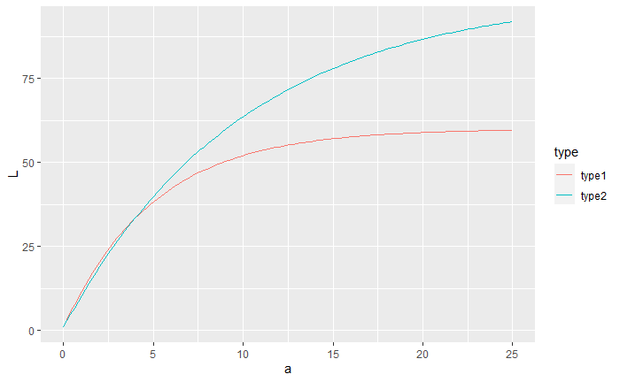

```r
library(ggplot2)
ages <- seq(0,25,0.2)
vb.L0 <- 1
vb.Linf <- c(60,100)
vb.k <- c(-0.2,-0.1)

vb.f <- function(a, L0, Linf, k){Linf + (L0 - Linf) * exp(k*a)}

vb.df <- rbind(
data.frame(type="type1",a=ages,L=vb.f(ages, vb.L0, vb.Linf[1], vb.k[1])),
data.frame(type="type2",a=ages,L=vb.f(ages, vb.L0, vb.Linf[2], vb.k[2]))
)
g <- ggplot(vb.df, aes(x=a,y=L)) + geom_line(aes(col=type))
g
```

So the “k” parameter in a VB should really not be interpreted as a“growth rate”.

## Age-length pairs

This is the run-of-the-mill data collected after examination of otoliths. We have the details of the individual fish from which the otoliths was collected, when and where it was caught, its length and weight, its sex, its maturity status.

```r
## generate 1E06 growth trajectories
set.seed(1973)

vb.L0 <- 2
## VB Linf
vb.Linf.mean <- 60
vb.Linf.sd <- 10

## VB k
vb.k.mean <- 0.25
vb.k.sd <- 0.05

n.sim <- 1E06
fish.number <- 1:n.sim
fish.Linf <- rnorm(n.sim, vb.Linf.mean, vb.Linf.sd)
fish.k <- rnorm(n.sim, vb.k.mean, vb.k.sd)

fishes <- data.frame(
  fish.number=rep(fish.number, each=20),
  Linf=rep(fish.Linf, each=20),
  k=rep(fish.k, each=20),
  age=rep(1:20, n.sim)
  )
fishes$u.id <- paste(fishes$fish.number, fishes$age, sep="-")
```

## Growth increments

An alternative but more demanding way is to examine an otolith under a microscope and to measure the radius of each ring along a pre-determined axis.

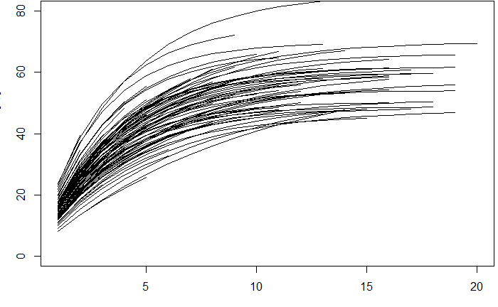

```r
## now identify 100 individuals and use their growth trajectories
n.detail <- 100

n.sim <- 1E06

detail.df <- data.frame(fish.number=sample(1:n.sim, n.detail, replace=FALSE), age=sample(1:20, n.detail, replace=TRUE))
detail.df$u.id <- paste(detail.df$fish.number, detail.df$age, sep="-")

back.calc.df <- data.frame(fish.number=-99, Linf=-99, k=-99, age=-99, u.id="-99-99", length=-99)

## for each fish, keep only the ages before its capture
## for JAGS
n.rows <- length(unique(detail.df$fish.number))
for.fish.matrix <- matrix(rep(NA, 20*n.rows), nr=n.rows)
dimnames(for.fish.matrix) <- list(fish.number=unique(detail.df$fish.number), age=1:20)

for(f in 1:n.detail){
  this.fish <- detail.df$fish.number[f]
  this.age <- detail.df$age[f]
  temp.df <- fishes[fishes$fish.number==this.fish & fishes$age <= this.age,]
  back.calc.df <- rbind(back.calc.df, temp.df)
  for.fish.matrix[as.character(this.fish),1:nrow(temp.df)] <- temp.df$length
}

back.calc.df <- back.calc.df[2:nrow(back.calc.df),]

par(mar=c(3,3,0.1,0.3))
plot(1:20, for.fish.matrix[1,], xlim=c(1,20), ylim=c(0,80), type='l')
for(r in 2:100){points(1:20,for.fish.matrix[r,],type='l')}
```

```r
## organise data for JAGS
dat <- list(N=n.detail, age=detail.df$age, fish.matrix=for.fish.matrix)

inits<-list(list(L0=vb.L0, Linf=vb.Linf.mean, k=vb.k.mean))

params<-c('L0','Linf','k')
set.seed(1973)

require(runjags)
require(coda)
##### MCMC DIMENSIONS #####
ni = 500
nb = 2000
na = 1000
nt = 10
nc = 3
n.iter = ni + nb

##### RUN THE MODEL IN JAGS #####

runJagsOut <- run.jags(model="growth-increments-mixed-effects.txt" ,
monitor=params ,
data=dat ,
#inits = inits,
n.chains=nc ,
adapt=na ,
burnin=nb ,
sample=ni ,
thin=nt ,
summarise=FALSE ,
plots=FALSE )
```

```
No initial values were provided - JAGS will use the same initial values for all chains
```

[output not shown]

[output cut: 154 more lines]

[output not shown]

```r
ss <- summary(runJagsOut)
```

```
Calculating summary statistics...
Calculating the Gelman-Rubin statistic for 300 variables....
```

```r
vb.L0
```

```
[1] 2
```

```r
## VB Linf
vb.Linf.mean
```

```
[1] 60
```

```r
vb.Linf.sd
```

```
[1] 10
```

```r
## VB k
vb.k.mean
```

```
[1] 0.25
```

```r
vb.k.sd
```

```
[1] 0.05
```

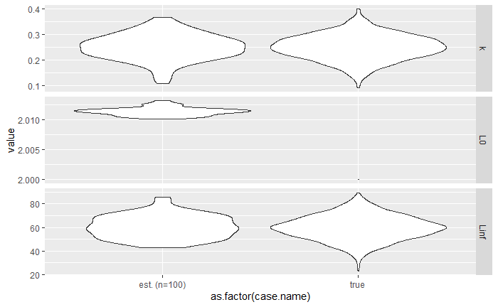

```r
nn <- 1000
for.gg <- rbind(
  data.frame(param.name=rep(params,each=nn), case.name=rep("true",nn*length(params)), value=c(rnorm(nn,vb.L0,0), rnorm(nn,vb.Linf.mean, vb.Linf.sd), rnorm(nn,vb.k.mean,vb.k.sd))),
  data.frame(param.name=rep(params, each=100), case.name=rep("est. (n=100)",100), value=c(ss[1:100,4], ss[101:200,4], ss[201:300,4]))
)

library(ggplot2)
for.gg.long <- for.gg

p <- ggplot(for.gg.long, aes(x=as.factor(case.name), y=value)) +
  #geom_boxplot() +
  geom_violin() +
  facet_grid(rows = vars(param.name), scales="free")

p
```

```r
NA
NA
```

# Age-length keys and calculating catch-at-age

An age-length key is simply the number of fish collected at different age-length combinations.

This matrix is then used to calculate the age composition of catch based on the observed length frequencies of the catch.

We will use our simulations to examine how our perception of the age composition of the catch is influenced by whether we use age-length pairs or growth increments.